# STAT 511: Assignment #1

Rumil Legaspi

25 January 2021

# Assignment Questions

## **1. KNN 4th Edition End of Chapter 1 Questions**

*In a regression model, $\beta_{0}$ = 100, $\beta_{1}$ = 20, and $\sigma^2$ = 25. An observation on Y variable will be made for X = 5.*

$Y_{i}$ = $\beta_{0}$ *(intercept)* + $\beta_{1}$$X_{i}$ *(slope)(independent variable)* + $\epsilon_{i}$ *(error)*

y = 100 + 20$X_{i}$ + $\epsilon_{i}$

### (a). Can we compute the exact probability that Y will fall between 195 and 205? Explain.

**The probability cannot be calculated because with a simple linear regression model the mean of $\epsilon_{i}$ should equal 0. Because $\epsilon_{i}$ is unspecified we are missing information and cannot compute the exact probability.**

### (b). If the normal error regression model is applicable, can we now compute the exact probability that Y will fall between 195 and 205? If so, compute it.

*note: $\epsilon_{i}$ (error term) = 0 and follows a normal distribution*

For this problem we recall:

- 1. The Z score formula since we are dealing with a normal distribution. $\frac{X - \mu}{\sigma}$
- 2. How to find the probability between 2 points given a normal distribution.

*(aka find the z score which finds everything from the left and subtract it by the larger number to get the probability between a and b)*

- 3. And that we are also given $\sigma^2 = 25$ *(variance)* and $\sigma = 5$ *(Standard deviation)*

SO: $P( 195 \leq Y \leq 205) = P(\frac{195 - 200}{5}\leq \frac{X - \mu}{\sigma} \leq \frac{205 - 200}{5})$

$= P(-1 \leq z\leq 1)$

$= P(z < 1) - P(z<-1)$ *bigger number or b is P(z < 1)*

$= 0.841 - 0.158$ *converting numbers using pos/neg z table*

$= 0.683$

**The probability that Y will fall between the 195 and 205 is roughly 0.683.**

## **2. Grade Point Average Problem (Use R)**

*The director of admissions of a small college selected 120 students at random from the new freshman class in a study to determine whether a student’s grade point average (GPA) at the end of the freshman year (Y) can be predicted from the ACT test score (X). See the dataset “GPA.txt”. The first column is GPA. The second column is ACT.*

```r
setwd("C:/Users/RUMIL/Desktop/APU/STAT 511 - Millie Mao (Applied Regression Analysis)/Week 1/STAT511 Assignment 1 Simple Linear Regression")


gpa_data = read.table(file = "GPA.txt", header = FALSE, sep = "")

#Adding headers
names(gpa_data) <- c("GPA", "ACT")
head(gpa_data)
```

|  | GPA | ACT |
| --- | --- | --- |
| 1 | 3.897 | 21 |
| 2 | 3.885 | 14 |
| 3 | 3.778 | 28 |
| 4 | 2.540 | 22 |
| 5 | 3.028 | 21 |
| 6 | 3.865 | 31 |

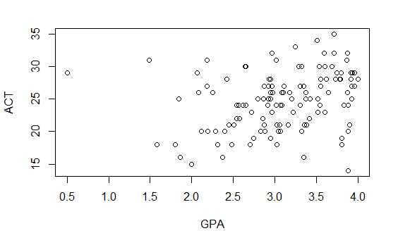

```r
#Defining dependent and independent vars
GPA = gpa_data$GPA
ACT = gpa_data$ACT

#scatterplot
plot(gpa_data)
```

### (a). Obtain the least squares estimates of $\beta_{0}$ and $\beta_{1}$. Write down the estimated regression equation.

```r
lm(GPA ~ ACT, data = gpa_data)
```

```
Call:
lm(formula = GPA ~ ACT, data = gpa_data)

Coefficients:
(Intercept)          ACT
    2.11405      0.03883
```

```r
#ACT Score is our response, GPA is our explanatory.
# in other words `ACT Score`~ GPA says, ACT is explained by GPA
gpa_lm = lm(GPA ~ ACT, data = gpa_data)
summary(gpa_lm)
```

```
Call:
lm(formula = GPA ~ ACT, data = gpa_data)

Residuals:
     Min       1Q   Median       3Q      Max
-2.74004 -0.33827  0.04062  0.44064  1.22737

Coefficients:
            Estimate Std. Error t value Pr(>|t|)
(Intercept)  2.11405    0.32089   6.588  1.3e-09
ACT          0.03883    0.01277   3.040  0.00292

(Intercept) ***
ACT         **
---
Signif. codes:
0 ‘***’ 0.001 ‘**’ 0.01 ‘*’ 0.05 ‘.’ 0.1 ‘ ’ 1

Residual standard error: 0.6231 on 118 degrees of freedom
Multiple R-squared:  0.07262,   Adjusted R-squared:  0.06476
F-statistic:  9.24 on 1 and 118 DF,  p-value: 0.002917
```

From the lm() we get:

**$\beta_{0}$ = 2.11405 *(intercept)***

**$\beta_{1}$ = 0.03883 *(slope)***

and the estimated regression equation to be:

**$\hat{Y}= 2.11405 + 0.03883X$**

### (b). Plot the estimated regression line and the data points. Does the estimated regression function appear to fit the data well?

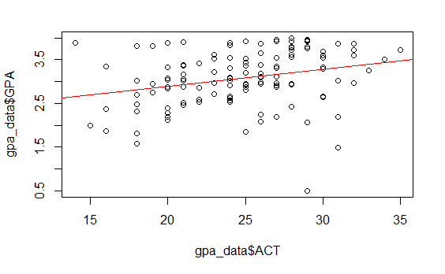

```r
plot(gpa_data$ACT, gpa_data$GPA)
gpa_lm = lm(GPA ~ ACT, data = gpa_data)
abline(gpa_lm, col = "red")
```

### (c). Obtain a point estimate of the mean freshman GPA for students with ACT test score 𝑋 = 30.

Using $\hat{Y}= 2.11405 + 0.03883X$ Solve for point estimate when x = 30

```r
#2.11405 + 0.03883*30 = Y hat
2.11405 + 0.03883*30
```

```
[1] 3.27895
```

**$\hat{Y}=3.27895$**

### (d). What is the estimated change in the mean response when the ACT score increases by one point?

The change in Y can be found using this formula: $\delta{y}= \hat{\beta_1} *\delta{x}$

```r
#Delta_y = beta1_hat * delta_X

#Change in y equals the slope multiplied by X in this case x = 1
DeltaY_gpa <- 0.03883*1

DeltaY_gpa
```

[output not shown]

**The change in mean response is 0.03883**

**Estimated change in $\hat{Y}$ (GPA) when ACT score increases by one point is 0.03883 .**

## **3. Refer to the GPA problem in Question 2. (Use R)**

### (a). Obtain the residuals $\hat{\epsilon_1}$. Do they sum to zero?

```r
#Finding predicted values of X using estimated regression equation
yhat <- 2.11405 + 0.03883*ACT

#Finding residual by doing observed minus predicted
e1_hat <- GPA - yhat
e1_hat

#Summing residuals to see if adds up to 0
sum(e1_hat)
```

[output not shown]

### (b). Estimate the error variance $\sigma^2$ and standard deviation $\sigma$. In what units is $\sigma$ expressed?

```r
#Squaring the residual standard error from our summary to get error variance
err_var <- 0.6231^2
err_var
```

[output not shown]

**$\sigma$ is expressed in units of standard deviation and in this case in terms of grade point averages (GPA).**

## **4. Refer to the GPA problem in Question 2.**

### (b). Interpret $\hat{\beta_1}$ in your estimated regression function.

$\hat{\beta_1}$ is also a coefficient which indicates the slope. This slope can help us indicate at which direction and what rate our regression line is going.

### (c). Verify that your fitted regression line goes through the point ($\bar{𝑋}$ , $\bar{Y}$). (Use R)

We plug in values for x and y in our regression line formula to test.

```r
#sample mean of x = 24.725
mean(ACT)

#sample mean of y = 3.07405
mean(GPA)

#So then this regression line formula should hold true if it intersects sample mean of x and y

#plugging in sample mean into estimated regression equation

#3.07405 = 2.11405 + 0.03883 * mean(ACT)
 2.11405 + 0.03883 * mean(ACT)
 mean(GPA)
```

[output not shown]

## **5. Muscle Mass Problem (Use R)**

*A person’s muscle mass is expected to decrease with age. To explore this relationship in women, a nutritionist randomly selected 15 women from each l0-year age group, beginning with age 40 and ending with age 79. 𝑋 is age, and Y is a measure of muscle mass. See the dataset “Muscle.txt”. The first column is muscle mass. The second column is women’s age.* _

```r
setwd("C:/Users/RUMIL/Desktop/APU/STAT 511 - Millie Mao (Applied Regression Analysis)/Week 1/STAT511 Assignment 1 Simple Linear Regression")


muscle_data = read.table(file = "Muscle.txt", header = FALSE, sep = "")
head(muscle_data)

#No headers, so we add
names(muscle_data) <- c("Muscle", "Age")
head(muscle_data)

#Defining dependent and independent vars
Age = muscle_data$Age #X
Muscle = muscle_data$Muscle #Y


#scatterplot
plot(muscle_data)
```

[output not shown]

### (a). Obtain the estimated regression equation.

```r
lm(Muscle ~ Age, data = muscle_data)

#Muscle is our response, Age is our explanatory.
#in other words Muscle ~ Age says, muscle mass is explained by Age

muscle_lm = lm(Muscle ~ Age, data = muscle_data)
summary(muscle_lm)
```

[output not shown]

### (b). Interpret $\beta_{0}$ in your estimated regression function. Does $\beta_{0}$ provide any relevant information here? Explain.

In this case $\beta_{0} = 156.35$ is our y-intercept and shows us the where the value of our response variable *(muscle)* is located when X *(age)* is 0. At the moment the y-intercept looks to be off-chart and is unable to provide any relevant information.

### (c). Interpret $\hat{\beta_1}$ in your estimated regression function.

$\hat{\beta_1} = -1.19$ is our slope and indicates that our estimated line is moving in a downward fashion.

### (d). Plot the estimated regression function and the data points. Does a linear regression function appear to give a good fit here? Does your plot support that muscle mass decreases with age?

```r
plot(muscle_data$Age, muscle_data$Muscle)
abline(muscle_lm, col = "red")
```

[output not shown]

### (e). Obtain a point estimate of the difference in the mean muscle mass for women differing in age by one year.

```r
#Delta_y = beta1_hat * delta_X
#Change in y equals the slope multiplied by X in this case x = 1
DeltaY_muscle <- -1.19*1

DeltaY_muscle
```

[output not shown]

Our slope $\hat{\beta_1} = -1.19$ indicates the change in Muscle Mass when adjusting age by one year

### (f). Obtain a point estimate of the mean muscle mass for women aged 𝑋 = 60 years.

$\hat{y} = 156.35 + -1.19x$

```r
whenAgeIs60 <- 156.35 + -1.19*60
whenAgeIs60
```

[output not shown]

$\hat{y} = 84.95$ when x = 60

### (g). Find the estimate of error variance $\sigma^2$

Point estimate for error variance: $\sigma^2={66.79}$

## **6. Special regression models**

### (a). What is the implication for the regression model $Y_{i}$ = $\beta_{0}$ + $\epsilon_{i}$ ? How does it plot on a graph?

When $\beta_{1}X_{i}=0$ and not accounted for, this tells us the slope is 0 and there is no change in our response variable.

Furthermore, in this case our dependent variable Y is actually now an independent variable and would make our regression line a straight horizontal line.

### (b). What is the implication for the regression model $Y_{i}$ = $\beta_{1}X_{i}$ + $\epsilon_{i}$ ? How does it plot on a graph?

When $\beta_{0} = 0$ *(y-intercept)* (the regression line crosses the origin point (0,0).